# Team Final Project

2022-04-29

1. Load the libraries that you will use in this project.

```r
#install.packages('dplyr')
#install.packages('magrittr')
#install.packages('lubridate')
#install.packages('stringr')
#install.packages('tidyr')
library(dplyr)
library(magrittr)
library(lubridate)
library(stringr)
library(tidyr)
```

2. Read in the data from the ities.csv and max_temp.csv files as dataframe objects df and df_weather_weekly respectively.

```r
df <- read.csv("ities.csv"
               , stringsAsFactors = T)
df_weather_weekly <- read.csv("max_temp.csv")
```

3. (1 point) Use an appropriate R function to display the number of rows and columns in the df and df_weather dataframes.

```r
dim(df)
```

```
## [1] 438151     13
```

```r
dim(df_weather_weekly)
```

```
## [1] 52  9
```

4. (4 points) Using any functions you want, make any necessary datatype conversions to columns in df and/or df_weather_weekly. Display the structures of the dataframes, df and df_weather_weekly to verify that the datatype conversions, if any, worked. Below the output, comment on why you did or did not make datatype conversions. (You may want to come back to this task and update it once you start working on the subsequent tasks.)

```r
#Section 1
df$Department <- str_to_lower(df$Department)
df$LineItem <- str_to_lower(df$LineItem)
df$Category <- str_to_lower(df$Category)

#Section 2
df_weather_weekly <- df_weather_weekly %>%
  relocate(WeekStarting, .before = Monday)

#Section 3
df_weather_weekly$Week <- NULL

#Section 4
df$Date <- mdy(df$Date)
df_weather_weekly$WeekStarting <- mdy(df_weather_weekly$WeekStarting)

#Section 5
df <- df %>%
  arrange(Date)
```

*1. Section 1 : convert the Department, LineItem and Category to lower case to make it easier to utilize the data by conforming.* *2. Section 2: Relocate the WeekStarting as the first column to join the data easier in the suceeeding steps.* *3. Section 3: Delete Week column since it’s repeating the row numbers to simplify the dataframe.* *4. Section 4: Convert the factors or characters to date to tidy the data frame for ease of use in the succeeding steps.* *5. Section 5: Arrange the data by acending order to make it similar to df_weather_weekly*

5. (1 point) Display summaries of the columns in the dataframes, df and df_weather_weekly.

```r
summary(df)
```

```
##       Date            OperationType            CashierName
##  Min.   :2014-01-04   RETURN:   349   Wallace Kuiper : 79328
##  1st Qu.:2014-09-11   SALE  :437802   Irving Burgos  : 25015
##  Median :2015-06-26                   Diana Miller   : 24869
##  Mean   :2015-07-11                   Rachael Price  : 24346
##  3rd Qu.:2016-04-26                   Vincent Ball   : 23552
##  Max.   :2017-04-05                   Stephanie Raven: 20728
##                                       (Other)        :240313
##    LineItem          Department          Category          RegisterName
##  Length:438151      Length:438151      Length:438151      RT149  :160786
##  Class :character   Class :character   Class :character   RT147  :109264
##  Mode  :character   Mode  :character   Mode  :character   RT145  : 67648
##                                                           RT135  : 24999
##                                                           RT146  : 21145
##                                                           RT151  : 20092
##                                                           (Other): 34217
##      StoreNumber         TransactionNumber       CustomerCode
##  AZ23501305: 72601   00XHLAF147696:    64   CWM11331L8O:393645
##  AZ23501336: 51362   00QG7IM183127:    45   CNJ6039IN9 :   162
##  AZ23501367: 34748   00HIKMB68419 :    42   CJ04273UTK :    82
##  AZ23501596: 33203   00N79DD84626 :    40   C9E3494ICE :    75
##  AZ23501258: 32246   00SMJ8R148203:    39   C5D11136WBI:    72
##  AZ23501289: 29390   009DZG9134033:    37   CZW6572NTE :    68
##  (Other)   :184601   (Other)      :437884   (Other)    : 44047
##      Price             Quantity          TotalDue
##  Min.   :-5740.51   Min.   :  1.000   Min.   :-5740.51
##  1st Qu.:    4.50   1st Qu.:  1.000   1st Qu.:    4.50
##  Median :   11.29   Median :  1.000   Median :   11.80
##  Mean   :   14.36   Mean   :  1.177   Mean   :   15.26
##  3rd Qu.:   14.68   3rd Qu.:  1.000   3rd Qu.:   15.04
##  Max.   :21449.97   Max.   :815.000   Max.   :21449.97
##  NA's   :12                           NA's   :12
```

```r
summary(df_weather_weekly)
```

```
##   WeekStarting            Monday          Tuesday         Wednesday
##  Min.   :2016-01-03   Min.   : 33.98   Min.   : 28.94   Min.   : 30.92
##  1st Qu.:2016-04-01   1st Qu.: 48.92   1st Qu.: 50.00   1st Qu.: 51.98
##  Median :2016-06-29   Median : 67.46   Median : 68.00   Median : 65.93
##  Mean   :2016-06-29   Mean   : 68.29   Mean   : 68.12   Mean   : 69.19
##  3rd Qu.:2016-09-26   3rd Qu.: 88.30   3rd Qu.: 87.58   3rd Qu.: 89.28
##  Max.   :2016-12-25   Max.   :100.94   Max.   :100.94   Max.   :102.02
##     Thursday          Friday          Saturday          Sunday
##  Min.   : 30.92   Min.   : 33.08   Min.   : 28.94   Min.   : 33.98
##  1st Qu.: 50.54   1st Qu.: 55.45   1st Qu.: 53.96   1st Qu.: 51.98
##  Median : 67.01   Median : 65.03   Median : 68.54   Median : 70.52
##  Mean   : 69.41   Mean   : 70.68   Mean   : 70.58   Mean   : 69.25
##  3rd Qu.: 89.56   3rd Qu.: 91.27   3rd Qu.: 89.56   3rd Qu.: 89.96
##  Max.   :100.94   Max.   :104.00   Max.   :102.02   Max.   :102.92
```

6. (3 points) Display the count of missing values in each column of df. Choose to remove or impute the missing values and defend that choice in 1-2 sentences for each column with missing values.

```r
#Imputing the missing values to median price.
summary(df$Price, df$TotalDue)
```

```
##     Min.  1st Qu.   Median     Mean  3rd Qu.     Max.     NA's
## -5740.51     4.50    11.29    14.36    14.68 21449.97       12
```

```r
df <- df %>%
  mutate(
    Price = ifelse(is.na(Price), median(Price, na.rm = T), Price)
    , TotalDue = Price * Quantity
  )
```

*All three variable Means are higher than medians. Which means the distribution is positively skewed. That’s why missing values were imputed using median values to dampen the effect of the outliers.*

7. (4 points) Let’s now explore whether there is a relationship in daily sales among the quantity purchased, the price paid, and the maximum temperature. To do so, we will want to aggregate the data at the daily level. Thus, please start by creating a new dataset df_daily by aggregating the dataframe df at the daily level. The dataframe df_daily must have the columns Quantity and TotalDue from df summarized at the daily level. Display a summary of df_daily. In one to two sentences defend the choice of summary measure (sum, mean, or other) used to aggregate the values in each column.

```r
#Making df_daily from df.
df_daily <- df %>%
  mutate(
    date = round_date(Date, 'day')
  ) %>%
  group_by(Date) %>%
  summarise(
    AvgPrice = mean(Price, na.rm = T)
    , MedPrice = median(Price, na.rm = T)
    , Quantity = n()
    , TotalDue = sum(TotalDue, na.rm = T)
  ) %>%
  ungroup()
summary(df_daily)
```

```
##       Date               AvgPrice           MedPrice        Quantity
##  Min.   :2014-01-04   Min.   :  0.0275   Min.   : 0.11   Min.   :   1.0
##  1st Qu.:2014-10-25   1st Qu.: 11.6470   1st Qu.:10.99   1st Qu.: 335.0
##  Median :2015-08-17   Median : 12.6970   Median :11.20   Median : 408.0
##  Mean   :2015-08-18   Mean   : 15.1923   Mean   :11.61   Mean   : 429.1
##  3rd Qu.:2016-06-11   3rd Qu.: 15.1801   3rd Qu.:12.02   3rd Qu.: 513.0
##  Max.   :2017-04-05   Max.   :390.0400   Max.   :75.09   Max.   :1056.0
##     TotalDue
##  Min.   : -149.6
##  1st Qu.: 4649.9
##  Median : 5971.0
##  Mean   : 6546.7
##  3rd Qu.: 7969.7
##  Max.   :26377.9
```

8. (4 points) Create a new dataframe, df_weather_daily, by pivoting the dataframe df_weather_weekly from wide to long such that names of the seven columns (Monday:Sunday) are in a new column day and the values from those seven columns (Monday:Sunday) are in a new column max_temp. Display the first 10 rows of df_weather_daily to verify that the pivot worked.

```r
#Converting df_weather_weekly to daily by pivoting the weekly weather dataframe.
df_weather_daily <- df_weather_weekly %>%
  pivot_longer(cols = c(Monday:Sunday)
              , names_to = 'DayoftheWeek'
              , values_to = 'Max Temp')

#Proof the pivot worked.
df_weather_daily[1:10,]
```

```
## # A tibble: 10 × 3
##    WeekStarting DayoftheWeek `Max Temp`
##    <date>       <chr>             <dbl>
##  1 2016-01-03   Monday             46.9
##  2 2016-01-03   Tuesday            45.0
##  3 2016-01-03   Wednesday          41
##  4 2016-01-03   Thursday           45.0
##  5 2016-01-03   Friday             59
##  6 2016-01-03   Saturday           57.0
##  7 2016-01-03   Sunday             57.0
##  8 2016-01-10   Monday             48.9
##  9 2016-01-10   Tuesday            46.0
## 10 2016-01-10   Wednesday          46.0
```

9. (4 points) Update the df_weather_daily dataframe by adding a column, Date, that corresponds to the value in the day column. For example, if the WeekStarting value is “2016-01-03”, then the value in the Date column for the Monday that comes after “2016-01-03” should have a value of “2016-01-04”. Arrange df_weather_daily in ascending order of Date and display the first 10 rows to verify that it worked. Beneath the output comment on how you know that the creation of the Date column worked.

```r
#Adding Date column from 2016-01-03 to 2016-12-31.
df_weather_daily$Date <- seq(as.Date('2016-01-03'), as.Date('2016-12-31'), 'days')

#Relocate Date column to the first column.
df_weather_daily <- df_weather_daily %>%
  relocate(Date, .before = WeekStarting)

#Show first 10 rows and 3 columns to verify that the creation of the Date column worked.
df_weather_daily[1:10,1:3]
```

```
## # A tibble: 10 × 3
##    Date       WeekStarting DayoftheWeek
##    <date>     <date>       <chr>
##  1 2016-01-03 2016-01-03   Monday
##  2 2016-01-04 2016-01-03   Tuesday
##  3 2016-01-05 2016-01-03   Wednesday
##  4 2016-01-06 2016-01-03   Thursday
##  5 2016-01-07 2016-01-03   Friday
##  6 2016-01-08 2016-01-03   Saturday
##  7 2016-01-09 2016-01-03   Sunday
##  8 2016-01-10 2016-01-10   Monday
##  9 2016-01-11 2016-01-10   Tuesday
## 10 2016-01-12 2016-01-10   Wednesday
```

10. (2 points) Join the dataframes df_daily and df_weather_daily into one dataframe df_final such that only the rows that are in both df_daily and df_weather_daily are in df_final. Arrange df_final in ascending order of Date. Then display something to show that the join worked. Briefly identify how that output helps you know that the join worked.

```r
#Join the dataframes in a way that only the rows that are in both dataframes in acending order of date.
df_final <- df_daily %>%
  inner_join(df_weather_daily, by = 'Date')

#Disable WeekStarting on the df_final
df_final$WeekStarting <- NULL

#Relocate DayoftheWeek column to the second column.
df_final <- df_final %>%
  relocate(DayoftheWeek, .after = Date)

#Output Back-test
summary(df_final$Date)
```

```
##         Min.      1st Qu.       Median         Mean      3rd Qu.         Max.
## "2016-01-05" "2016-04-03" "2016-07-02" "2016-07-02" "2016-09-29" "2016-12-31"
```

```r
df_daily[df_daily$Date >= '2016-01-05' & df_daily$Date <= '2016-12-31',]
```

```
## # A tibble: 311 × 5
##    Date       AvgPrice MedPrice Quantity TotalDue
##    <date>        <dbl>    <dbl>    <int>    <dbl>
##  1 2016-01-05     11.7     11.9      272    3358.
##  2 2016-01-06     11.6     12.0      299    3935.
##  3 2016-01-07     17.3     12.0      332    5966.
##  4 2016-01-08     11.5     11.7      516    6193.
##  5 2016-01-09     11.9     12.2      490    6857.
##  6 2016-01-11     12.6     11.0      302    4077.
##  7 2016-01-12     11.6     11.0      296    3518.
##  8 2016-01-13     19.6     12.0      289    6277.
##  9 2016-01-14     11.9     11.3      399    5032.
## 10 2016-01-15     11.4     11.0      519    6282.
## # … with 301 more rows
```

11. (4 points) Display a pairplot like the one demonstrated towards the end of the module 2 video, “Getting to Know Your Data 3: Summary Statistics for Each Column, and Quick Plots”. Create this pairplot for three columns from df_final: Quantity, TotalDue, and max_temp. Below the output, identify whether there appears to be a two-way relationship for each of the two-way combination of variables: Quantity & TotalDue, Quantity & max_temp, and TotalDue & max_temp.

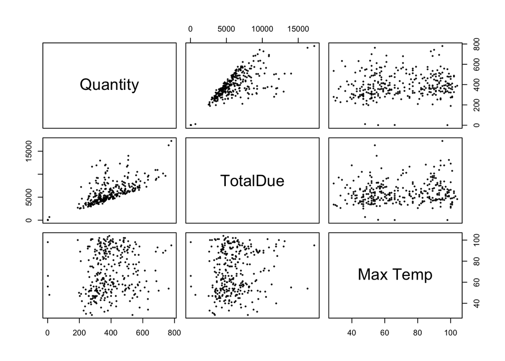

```r
plot(df_final[,c('Quantity', 'TotalDue', 'Max Temp')], cex = 0.3)
```

### Two-Way Relationship Comparison

1. Quantity & TotalDue: *A positive correlation can be observed between these two variables.*
2. Quantity & Max_Temp: *A weak or neutral correlation can be observed between these two variables.*
3. TotalDue & Max_Temp: *A weak or neutral correlation between these two variables.*